# Handwritten Digits Network

# 1 Used libraries and includes

```r
library(keras)
library(ggplot2)
library(shiny)
```

```r
(keras::backend())$backend()
```

```
[1] "tensorflow"
```

# 3 Loading and Visualizing Data

Loading data:

```r
image_size <- 400
data <- R.matlab::readMat('data/data.mat')
X <- data[['X']]
y <- data[['y']]
n <- nrow(X)
```

Randomly select 100 data points to display:

```r
rotate <- function(x) t(apply(x, 2, rev))
displayDataArray <- function(sel) {
  n <- sqrt(nrow(sel))
  width <- sqrt(nrow(matrix(sel[1,])))
  height <- width
  full_img <- matrix(nrow = 0, ncol = width * n)
  for (i in 1:n) {
    row <- matrix(nrow = height, ncol = 0)
    for (j in 1:n) {
      img <- matrix(sel[n * (i - 1) + j,], nrow = height, ncol = width)
      row <- cbind(row, img)
    }
    full_img <- rbind(full_img, row)
  }
  full_img <- rotate(full_img)
  image(full_img, axes = FALSE, col = grey(seq(0, 1, length = 256)))
}
```

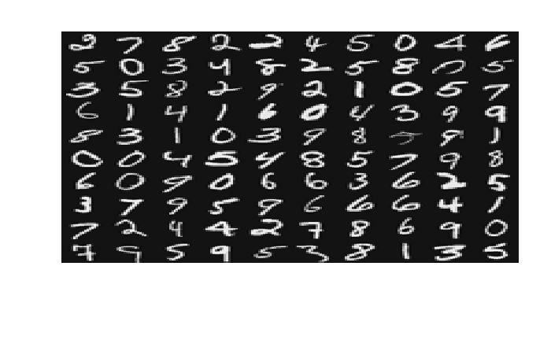

```r
displayDataArray(X[sample(nrow(X),size = 100),])
```

# 4 Keras

## 4.1 Already trained

### 4.1.1 Loading Parameters

Load the weights into variables Theta1 and Theta2

```r
weights <- R.matlab::readMat('data/weights.mat')
Theta1 <- weights[['Theta1']]
Theta2 <- weights[['Theta2']]
```

### 4.1.2 Load Weight Functions

```r
set_layer_weights <- function(model, index, theta) {
  current_weights <- model %>% get_layer(index = index) %>% get_weights()
  current_weights[[1]] = t(theta[,2:ncol(theta)])
  current_weights[[2]][] = c(theta[,1])[]
  model %>% get_layer(index = index) %>% set_weights(current_weights)
}
```

### 4.1.3 Create Model And Load Weights

```r
model <- keras_model_sequential()
model %>%
  layer_dense(units = 25, activation = "sigmoid", input_shape = c(image_size)) %>%
  layer_dense(units = 10, activation = "sigmoid")
model %>% set_layer_weights(1, Theta1)
model %>% set_layer_weights(2, Theta2)
summary(model)
```

```
_______________________________________________________________________________________________________________________________________________________________
Layer (type)                                                           Output Shape                                                    Param #
===============================================================================================================================================================
dense_1 (Dense)                                                        (None, 25)                                                      10025
_______________________________________________________________________________________________________________________________________________________________
dense_2 (Dense)                                                        (None, 10)                                                      260
===============================================================================================================================================================
Total params: 10,285
Trainable params: 10,285
Non-trainable params: 0
_______________________________________________________________________________________________________________________________________________________________
```

```r
model %>% compile(
  loss = "categorical_crossentropy",
  optimizer = optimizer_adamax(),
  metrics = c("accuracy")
)
```

### 4.1.4 Evuluate Model

```r
accuracy <- (model %>% evaluate(X, to_categorical(y - 1, 10),verbose = 0))$acc
```

## 4.2 Implement Predict By Hand

### 4.2.1 Predict Function

```r
sigmoid <- function(z) {
  return(1.0 / (1.0 + exp(-z)))
}
predict <- function(Theta1, Theta2, X) {
  m <- nrow(X)
  extendedX <- cbind(matrix(1, m, 1), X)
  z2 <- extendedX %*% t(Theta1)
  a2 <- sigmoid(z2)
  extendeda2 <- cbind(matrix(1, m, 1), a2)
  z3 <- extendeda2 %*% t(Theta2)
  h <- sigmoid(z3)

  return(matrix(apply(h, 1, which.max)))
}
```

### 4.2.2 Evuluate Model

```r
accuracy <- mean(as.double(apply(predict(Theta1, Theta2, X),2,'==',y))) * 100
```

## 4.3 My Model

### 4.3.1 Prepare data

```r
n_train <- round(0.8 * n)
shuffled <- sample(n);
x_all <- X[shuffled,]
y_all <- to_categorical(y[shuffled,] - 1, 10)
x_train <- x_all[1:n_train,]
y_train <- y_all[1:n_train,]
x_test <- x_all[(n_train + 1):n,]
y_test <- y_all[(n_train + 1):n,]
```

#### 4.3.1.1 Create model and compile

```r
model <- keras_model_sequential()
model %>%
  layer_dense(units = 512, activation = "sigmoid", input_shape = c(image_size)) %>%
  layer_dense(units = 10, activation = "softmax")
model %>% compile(
  loss = "categorical_crossentropy",
  optimizer = optimizer_nadam(),
  metrics = c("accuracy")
)
summary(model)
```

```
_______________________________________________________________________________________________________________________________________________________________
Layer (type)                                                           Output Shape                                                    Param #
===============================================================================================================================================================
dense_3 (Dense)                                                        (None, 512)                                                     205312
_______________________________________________________________________________________________________________________________________________________________
dense_4 (Dense)                                                        (None, 10)                                                      5130
===============================================================================================================================================================
Total params: 210,442
Trainable params: 210,442
Non-trainable params: 0
_______________________________________________________________________________________________________________________________________________________________
```

### 4.3.2 Training and Evaluation

```r
history <- model %>% fit(
  x_train,
  y_train,
  epochs = 30,
  batch_size = 32,
  validation_data = list(x_test, y_test),
  shuffle = TRUE,
  #callbacks = callback_tensorboard("logs/run_a"),
  verbose = 2
)
```

```
Train on 4000 samples, validate on 1000 samples
 - 2s - loss: 0.9519 - acc: 0.7485 - val_loss: 0.4490 - val_acc: 0.8950
 - 1s - loss: 0.4136 - acc: 0.8862 - val_loss: 0.3325 - val_acc: 0.9150
 - 1s - loss: 0.3300 - acc: 0.9073 - val_loss: 0.2966 - val_acc: 0.9210
 - 1s - loss: 0.2821 - acc: 0.9193 - val_loss: 0.2745 - val_acc: 0.9230
 - 1s - loss: 0.2517 - acc: 0.9280 - val_loss: 0.2627 - val_acc: 0.9320
 - 1s - loss: 0.2264 - acc: 0.9323 - val_loss: 0.2598 - val_acc: 0.9220
 - 1s - loss: 0.2051 - acc: 0.9407 - val_loss: 0.2656 - val_acc: 0.9220
 - 1s - loss: 0.1883 - acc: 0.9465 - val_loss: 0.2554 - val_acc: 0.9340
 - 1s - loss: 0.1693 - acc: 0.9502 - val_loss: 0.2524 - val_acc: 0.9290
 - 1s - loss: 0.1494 - acc: 0.9580 - val_loss: 0.2693 - val_acc: 0.9210
 - 1s - loss: 0.1388 - acc: 0.9613 - val_loss: 0.2505 - val_acc: 0.9290
 - 1s - loss: 0.1216 - acc: 0.9657 - val_loss: 0.2474 - val_acc: 0.9330
 - 1s - loss: 0.1096 - acc: 0.9682 - val_loss: 0.2477 - val_acc: 0.9270
 - 1s - loss: 0.0980 - acc: 0.9715 - val_loss: 0.2446 - val_acc: 0.9410
 - 1s - loss: 0.0882 - acc: 0.9762 - val_loss: 0.2459 - val_acc: 0.9360
 - 1s - loss: 0.0781 - acc: 0.9808 - val_loss: 0.2490 - val_acc: 0.9350
 - 1s - loss: 0.0697 - acc: 0.9832 - val_loss: 0.2564 - val_acc: 0.9360
 - 1s - loss: 0.0624 - acc: 0.9830 - val_loss: 0.2513 - val_acc: 0.9370
 - 1s - loss: 0.0540 - acc: 0.9860 - val_loss: 0.2463 - val_acc: 0.9390
 - 1s - loss: 0.0492 - acc: 0.9870 - val_loss: 0.2566 - val_acc: 0.9380
 - 1s - loss: 0.0425 - acc: 0.9920 - val_loss: 0.2631 - val_acc: 0.9420
 - 1s - loss: 0.0370 - acc: 0.9928 - val_loss: 0.2534 - val_acc: 0.9420
 - 1s - loss: 0.0346 - acc: 0.9945 - val_loss: 0.2547 - val_acc: 0.9420
 - 1s - loss: 0.0287 - acc: 0.9950 - val_loss: 0.2545 - val_acc: 0.9440
 - 1s - loss: 0.0264 - acc: 0.9963 - val_loss: 0.2552 - val_acc: 0.9410
 - 1s - loss: 0.0223 - acc: 0.9975 - val_loss: 0.2557 - val_acc: 0.9460
 - 1s - loss: 0.0198 - acc: 0.9978 - val_loss: 0.2651 - val_acc: 0.9410
 - 1s - loss: 0.0174 - acc: 0.9990 - val_loss: 0.2657 - val_acc: 0.9420
 - 1s - loss: 0.0150 - acc: 0.9990 - val_loss: 0.2761 - val_acc: 0.9410
 - 1s - loss: 0.0130 - acc: 0.9993 - val_loss: 0.2714 - val_acc: 0.9380
```

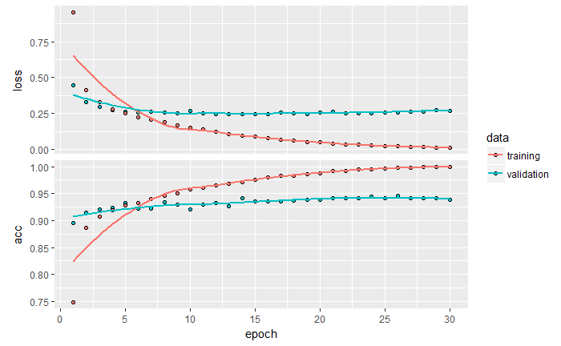

```r
plot(history)
```

### 4.3.3 Evaluate

```r
accuracy <- (model %>% evaluate(x_test, y_test,verbose = 0))$acc
```

### 4.3.4 Generate prediction

```r
prediction_keras <- model %>% predict_classes(x_test)
```

# 5 Test

## 5.1 By Hand

## 5.2 Display Functions

```r
displayData <- function(sel) {
  width <- sqrt(ncol(sel))
  mat <- matrix(sel, nrow = width, ncol = width)
  mat <- rotate(mat)
  image(mat, axes = FALSE, col = grey(seq(0, 1, length = 256)))
}
```

```r
displayRandomImageAndGetPrediction <- function(Theta1, Theta2, X) {
    # Select random image
    example <- t(matrix(X[sample(nrow(X), 1),]));

    # Display
    displayData(example);

    # Prediction
    return(c(predict(Theta1, Theta2, example)))
}
```

```r
library(shiny)
renderPlot({
  input$updateButton

  prediction <- displayRandomImageAndGetPrediction(Theta1, Theta2, X)
  output$prediction <- renderText({
    paste('Neural Network Prediction: ', prediction, '\n')
  })
}, width = 200, height = 200)
```

[output not shown]

```r
actionButton('updateButton', 'Update')
```

```r
textOutput('prediction')
```

## 5.3 My Model

```r
displayRandomImageAndGetPredictionKeras <- function(x, y) {
    # Select random image
    i <- sample(nrow(x), 1)
    example <- t(matrix(x[i,]));

    # Display
    displayData(example);

    # Prediction
    return(y[i])
}
```

```r
renderPlot({
  input$updateButton2

  prediction <- displayRandomImageAndGetPredictionKeras(x_test, prediction_keras)
  output$prediction2 <- renderText({
    paste('Neural Network Prediction: ', prediction, '\n')
  })
}, width = 200, height = 200)
```

[output not shown]

```r
actionButton('updateButton2', 'Update')
```

```r
textOutput('prediction2')
```

# 6 License

MIT License

Copyright (c) 2017 Konstantin Stukov

Permission is hereby granted, free of charge, to any person obtaining a copy of this software and associated documentation files (the “Software”), to deal in the Software without restriction, including without limitation the rights to use, copy, modify, merge, publish, distribute, sublicense, and/or sell copies of the Software, and to permit persons to whom the Software is furnished to do so, subject to the following conditions:

The above copyright notice and this permission notice shall be included in all copies or substantial portions of the Software.

THE SOFTWARE IS PROVIDED “AS IS”, WITHOUT WARRANTY OF ANY KIND, EXPRESS OR IMPLIED, INCLUDING BUT NOT LIMITED TO THE WARRANTIES OF MERCHANTABILITY, FITNESS FOR A PARTICULAR PURPOSE AND NONINFRINGEMENT. IN NO EVENT SHALL THE AUTHORS OR COPYRIGHT HOLDERS BE LIABLE FOR ANY CLAIM, DAMAGES OR OTHER LIABILITY, WHETHER IN AN ACTION OF CONTRACT, TORT OR OTHERWISE, ARISING FROM, OUT OF OR IN CONNECTION WITH THE SOFTWARE OR THE USE OR OTHER DEALINGS IN THE SOFTWARE.